# Final_Project_Script

Hans Kristian Erik Bruun Mortensen

2023-12-10

Starting with installing the necessary packages

```r
library(tidyverse)
```

```r
library(ggplot2)
```

Then i import my datasets into R

```r
China_Military_Personel <- read_csv2("Data_FP/China_Military_Personel.csv")
```

```
## ℹ Using "','" as decimal and "'.'" as grouping mark. Use `read_delim()` for more control.
```

```
## ──────────────────────────────────────────────────────── Delimiter: ";" chr
## (1): Nation dbl (2): Year, Military_Personel lgl (1): ...4
```

```r
USA_Military_Personel <- read_csv2("Data_FP/USA_Military_Personel.csv")
```

```
## ℹ Using "','" as decimal and "'.'" as grouping mark. Use `read_delim()` for more control.
```

```r
China_MilitaryGDP <- read_csv2("Data_FP/China_MilitaryGDP.csv")
```

```
## ℹ Using "','" as decimal and "'.'" as grouping mark. Use `read_delim()` for more control.
```

```r
USA_MilitaryGDP <- read_csv2("Data_FP/USA_MilitaryGDP.csv")
```

```
## ℹ Using "','" as decimal and "'.'" as grouping mark. Use `read_delim()` for more control.
```

```r
China_Nuclear_Stockpile_Development <- read_csv2("Data_FP/China_Nuclear_Stockpile_Development.csv")
```

```
## ℹ Using "','" as decimal and "'.'" as grouping mark. Use `read_delim()` for more control.
```

```r
China_Nuclear_Stockpile <- read_csv2("Data_FP/China_Nuclear_Stockpile.csv")
```

```
## ℹ Using "','" as decimal and "'.'" as grouping mark. Use `read_delim()` for more control.
```

```r
USA_Nuclear_Stockpile <- read_csv2("Data_FP/USA_Nuclear_Stockpile.csv")
```

```
## ℹ Using "','" as decimal and "'.'" as grouping mark. Use `read_delim()` for more control.
```

```r
USA_Nuclear_Stockpile_Development <- read_csv2("Data_FP/USA_Nuclear_Stockpile_Development.csv")
```

```
## ℹ Using "','" as decimal and "'.'" as grouping mark. Use `read_delim()` for more control.
```

```r
Nations_With_Nuclear_Weapons <- read_csv2("Data_FP/Nations_With_Nuclear_Weapons.csv")
```

```
## ℹ Using "','" as decimal and "'.'" as grouping mark. Use `read_delim()` for more control.
```

Now i want to inspect my data by using the str() function, so i can get an overview of how R reads my data

```r
str(China_Military_Personel)
```

```
## spc_tbl_ [39 × 4] (S3: spec_tbl_df/tbl_df/tbl/data.frame)
##  $ Nation           : chr [1:39] "China" "China" "China" "China" ...
##  $ Year             : num [1:39] 1978 1979 1980 1981 1982 ...
##  $ Military_Personel: num [1:39] 4500000 4600000 4650000 4750000 4350000 4100000 4100000 4100000 4030000 3530000 ...
##  $ ...4             : logi [1:39] NA NA NA NA NA NA ...
##  - attr(*, "spec")=
##   .. cols(
##   ..   Nation = col_character(),
##   ..   Year = col_double(),
##   ..   Military_Personel = col_double(),
##   ..   ...4 = col_logical()
##   .. )
##  - attr(*, "problems")=<externalptr>
```

```r
str(China_MilitaryGDP)
```

```
## spc_tbl_ [32 × 2] (S3: spec_tbl_df/tbl_df/tbl/data.frame)
##  $ Year              : num [1:32] 1989 1990 1991 1992 1993 ...
##  $ Percentages_of_GDP: num [1:32] 2.45 2.45 2.31 2.45 1.93 1.69 1.69 1.65 1.63 1.66 ...
##  - attr(*, "spec")=
##   .. cols(
##   ..   Year = col_double(),
##   ..   Percentages_of_GDP = col_double()
##   .. )
##  - attr(*, "problems")=<externalptr>
```

```r
str(USA_MilitaryGDP)
```

```
## spc_tbl_ [32 × 5] (S3: spec_tbl_df/tbl_df/tbl/data.frame)
##  $ Year              : num [1:32] 1989 1990 1991 1992 1993 ...
##  $ Percentages_of_GDP: num [1:32] 5.87 5.61 4.88 4.97 4.6 4.22 3.86 3.55 3.41 3.2 ...
##  $ ...3              : logi [1:32] NA NA NA NA NA NA ...
##  $ ...4              : logi [1:32] NA NA NA NA NA NA ...
##  $ ...5              : logi [1:32] NA NA NA NA NA NA ...
##  - attr(*, "spec")=
##   .. cols(
##   ..   Year = col_double(),
##   ..   Percentages_of_GDP = col_double(),
##   ..   ...3 = col_logical(),
##   ..   ...4 = col_logical(),
##   ..   ...5 = col_logical()
##   .. )
##  - attr(*, "problems")=<externalptr>
```

```r
str(China_Nuclear_Stockpile_Development)
```

```
## spc_tbl_ [47 × 4] (S3: spec_tbl_df/tbl_df/tbl/data.frame)
##  $ Nation                   : chr [1:47] "China" "China" "China" "China" ...
##  $ Year                     : num [1:47] 1978 1979 1980 1981 1982 ...
##  $ Nuclear_weapons-stockpile: num [1:47] 190 195 205 210 216 218 220 222 224 226 ...
##  $ ...4                     : logi [1:47] NA NA NA NA NA NA ...
##  - attr(*, "spec")=
##   .. cols(
##   ..   Nation = col_character(),
##   ..   Year = col_double(),
##   ..   `Nuclear_weapons-stockpile` = col_double(),
##   ..   ...4 = col_logical()
##   .. )
##  - attr(*, "problems")=<externalptr>
```

```r
str(China_Nuclear_Stockpile)
```

```
## spc_tbl_ [46 × 3] (S3: spec_tbl_df/tbl_df/tbl/data.frame)
##  $ Nation                   : chr [1:46] "China" "China" "China" "China" ...
##  $ Year                     : num [1:46] 1978 1979 1980 1981 1982 ...
##  $ Nuclear_weapons-stockpile: num [1:46] 190 195 205 210 216 218 220 222 224 226 ...
##  - attr(*, "spec")=
##   .. cols(
##   ..   `Nation ` = col_character(),
##   ..   Year = col_double(),
##   ..   `Nuclear_weapons-stockpile` = col_double()
##   .. )
##  - attr(*, "problems")=<externalptr>
```

```r
str(USA_Nuclear_Stockpile)
```

```
## spc_tbl_ [46 × 4] (S3: spec_tbl_df/tbl_df/tbl/data.frame)
##  $ Nation                   : chr [1:46] "United States" "United States" "United States" "United States" ...
##  $ Year                     : num [1:46] 1978 1979 1980 1981 1982 ...
##  $ Nuclear_weapons_stockpile: num [1:46] 24418 24138 24104 23208 22886 ...
##  $ ...4                     : logi [1:46] NA NA NA NA NA NA ...
##  - attr(*, "spec")=
##   .. cols(
##   ..   Nation = col_character(),
##   ..   Year = col_double(),
##   ..   Nuclear_weapons_stockpile = col_double(),
##   ..   ...4 = col_logical()
##   .. )
##  - attr(*, "problems")=<externalptr>
```

```r
str(USA_Nuclear_Stockpile_Development)
```

```
## spc_tbl_ [46 × 4] (S3: spec_tbl_df/tbl_df/tbl/data.frame)
##  $ Nation                  : chr [1:46] "United States" "United States" "United States" "United States" ...
##  $ Year                    : num [1:46] 1978 1979 1980 1981 1982 ...
##  $ Nuclear_weapon_stockpile: num [1:46] 24418 24138 24104 23208 22886 ...
##  $ ...4                    : logi [1:46] NA NA NA NA NA NA ...
##  - attr(*, "spec")=
##   .. cols(
##   ..   Nation = col_character(),
##   ..   Year = col_double(),
##   ..   Nuclear_weapon_stockpile = col_double(),
##   ..   ...4 = col_logical()
##   .. )
##  - attr(*, "problems")=<externalptr>
```

### my data

###Development in chinese and american military personal

Now i going to plot my data with ggplot, starting with the development in chinese military personel since 1978

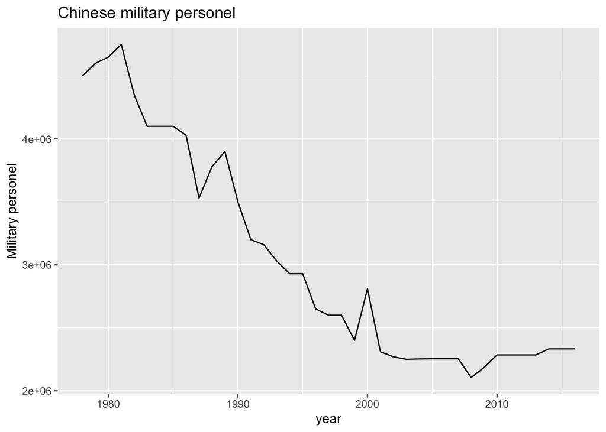

```r
ggplot(data = China_Military_Personel)+
  geom_line(mapping = aes(x = Year, y = Military_Personel))+
  labs(title = "Chinese military personel", y = "Military personel", x = "year")
```

Next up i want to make vizualise the american military personel since 1978

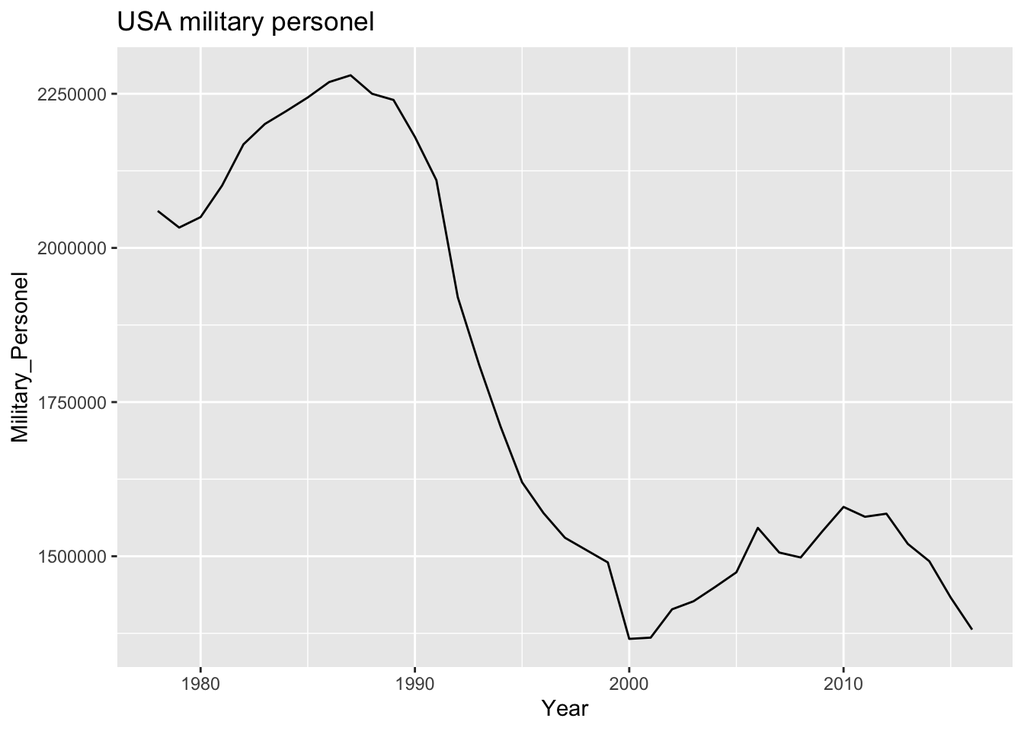

```r
ggplot(data = USA_Military_Personel)+
  geom_line(mapping = aes(x = Year, y = Military_Personel))+
  labs(title = "USA military personel")
```

###Development in chinese and american military expenditure as a share of GDP

In the following section i am going to visualize the procentage of GDP spend on military by each nation.Starting with China

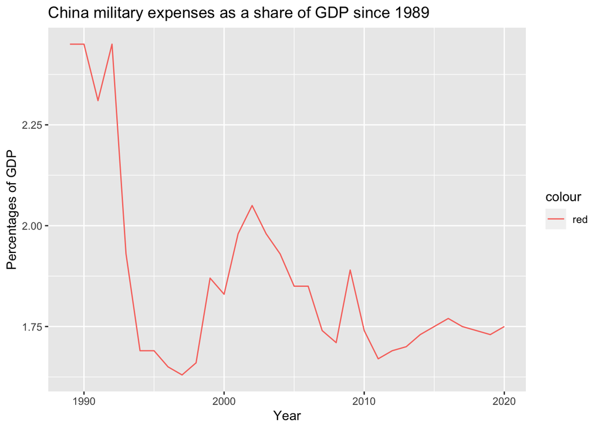

```r
ggplot(data = China_MilitaryGDP)+
  geom_line(mapping = aes(x = Year, y = Percentages_of_GDP, color = "red"))+
  labs(title = "China military expenses as a share of GDP since 1989", x = "Year", y = "Percentages of GDP")
```

And then USA

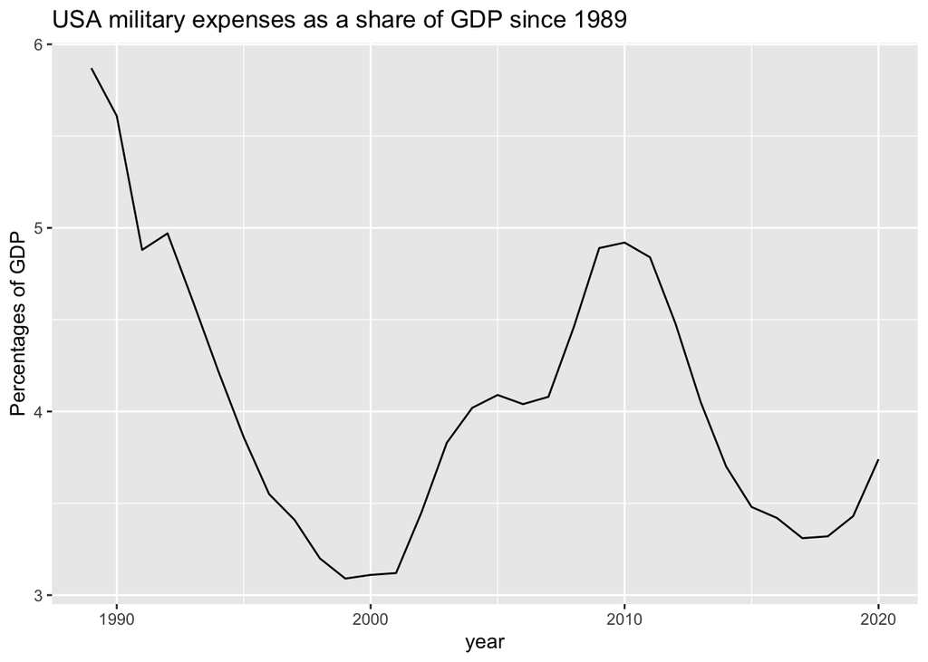

```r
ggplot(data = USA_MilitaryGDP)+
  geom_line(mapping = aes(x = Year, y = Percentages_of_GDP))+
  labs(title = "USA military expenses as a share of GDP since 1989", x = "year", y = "Percentages of GDP")
```

To create a better visualization i am going to merge the two graphs.

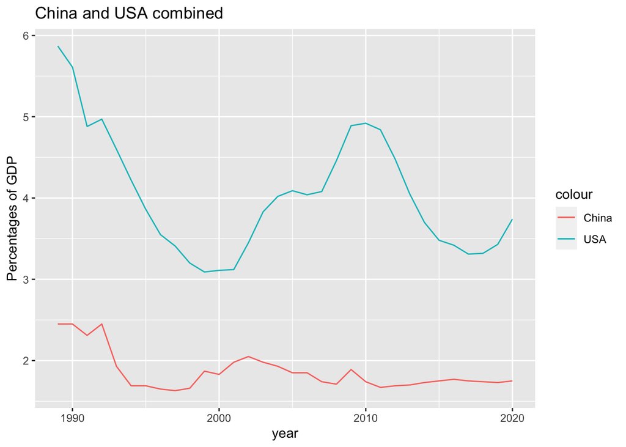

```r
ggplot()+
  geom_line(data = USA_MilitaryGDP, mapping = aes(x = Year, y = Percentages_of_GDP, color = "USA"))+
  geom_line(data = China_MilitaryGDP, mapping = aes(x = Year, y = Percentages_of_GDP, color = "China"))+
  labs(x = "year", y = "Percentages of GDP", title = "China and USA combined ")
```

###Chinese and american possesion of nuclear weapons

In this section i want to showcase the development in the amount of nuclear weapons each nations has possessed since 1978. Starting with China.

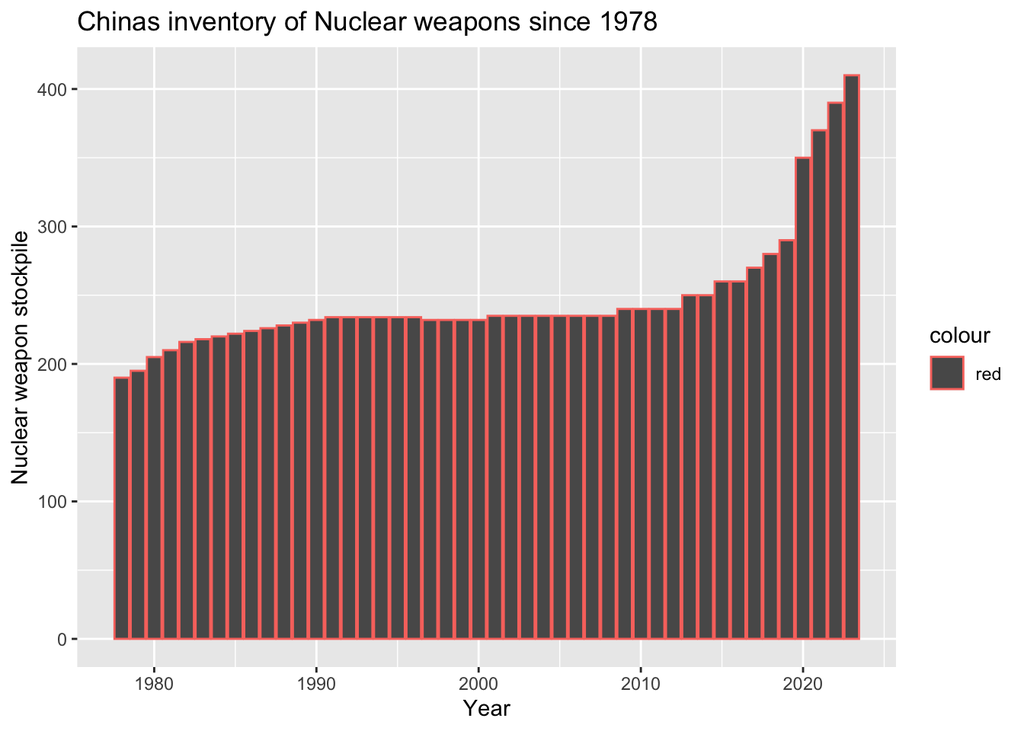

```r
ggplot(data = China_Nuclear_Stockpile_Development)+
  geom_col(mapping = aes(x =Year, y = China_Nuclear_Stockpile_Development$`Nuclear_weapons-stockpile`, color = "red"))+
  labs( y = "Nuclear weapon stockpile", x = "Year", title ="Chinas inventory of Nuclear weapons since 1978")
```

And now the United States.

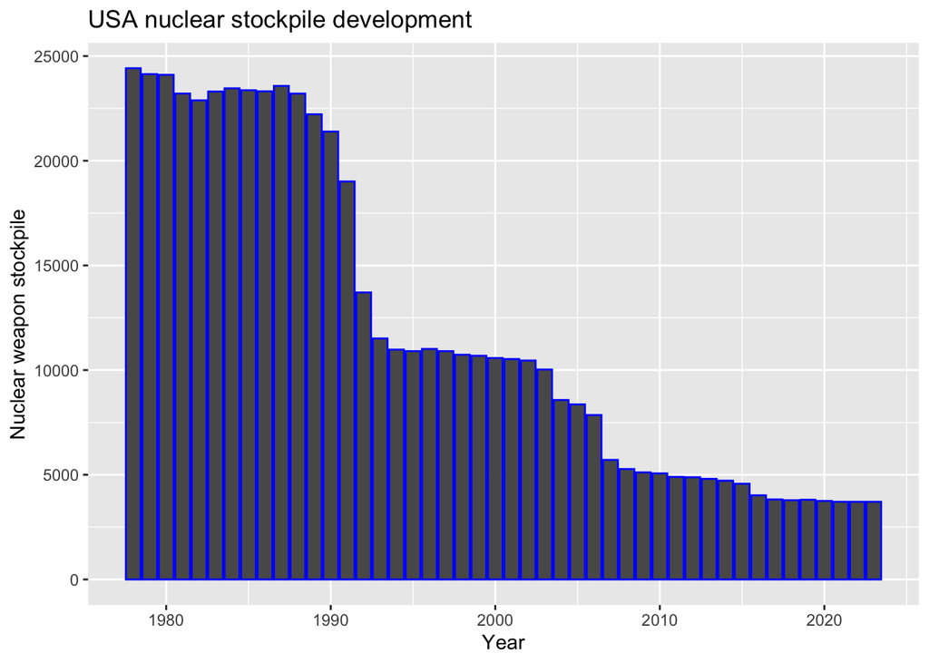

```r
ggplot(mapping = aes(x = USA_Nuclear_Stockpile_Development$Year, y = USA_Nuclear_Stockpile_Development$Nuclear_weapon_stockpile))+
  geom_col(colour = "blue")+
  labs(x = "Year", y = "Nuclear weapon stockpile", title = "USA nuclear stockpile development")
```

#Chinese and american possesion of nuclear weapons compared to the rest of the nations in possesion of nuclear weapons.

In this final section i am going to compare the 9 nations which possesses nuclear weapons.

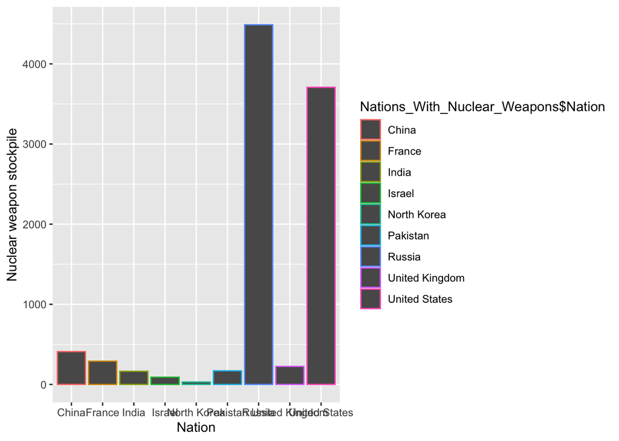

```r
ggplot(data = Nations_With_Nuclear_Weapons)+
  geom_col(mapping = aes(x = Nations_With_Nuclear_Weapons$Nation, y = Nations_With_Nuclear_Weapons$Nuclear_Weapon_Stocpile, colour = Nations_With_Nuclear_Weapons$Nation))+
  labs(x = "Nation", y = "Nuclear weapon stockpile")
```